# PEC1 Anàlisi de dades òmiques

Alex Vidal Romera

2024-11-03

## Abstract

La caquèxia, tal com defineixi el National Cancer Institute (NCI) és la pèrdua de pes corporal i massa muscular que produeix debilitat. Aquesta afecció a vegades es presenta en pacients amb càncer, SIDA o altres malalties cròniques. L’estudi dels diferents metabòlits en malalts de caquèxia pot ajudar a la identificació de biomarcadors específics de la malaltia així com a la identificació de diferents processos biològics associats. Alhora, el resultat d’una anàlisi exhaustiva de les dades pot obrir possibles portes a la investigació de tractaments relacionats amb els processos associats a la manca o excés de certs metabòlits.

## Objectius de l’estudi

L’objectiu principal d’aquesta prova d’avaluació continuada (PAC) és la culminació del procés d’introducció a les òmiques mitjançant el repàs i l’ampliació del contingut impartit durant el curs. Per a realitzar-ho, s’ha dividit la metodologia en diferents objectius:

- Familiaritzar-se amb les tecnologies òmiques.
- Treballar amb diferents eines utilitzades en l’anàlisi de dades òmiques com Bioconductor, expressionSets i GitHub.
- Crear un contenidor de tipus SummarizedExperiment que contingui les dades I metadades
- Realitzar una exploració del conjunt de dades seleccionat per a proporcionar una visió general d’aquest.
- Elaborar un informe descrivint el procés realitzat a la PAC.

## Materials i mètodes

### Obtenció de les dades

Les dades obtingudes per a la realització de l’exercici van ser obtingudes del l’enunciat.

Tal com es pot consultar al fitxer descriptiu, el conjunt de dades original es pot descarregar del següent enllaç: *https://rest.xialab.ca/api/download/metaboanalyst/human_cachexia.csv*.

### Eines informàtiques i bioinformàtiques

L’exercici s’ha realitzat amb el llenguatge de programació R, utilitzat per a computació estadística i la visualització de dades. Per a treballar més fàcilment amb aquest llenguatge, s’ha utilitzat l’entorn de desenvolupament integrat (IDE) Rstudio, tot i que qualsevol altre IDE és perfectament funcional. Rstudio proporciona una fàcil visualització i execució del codi alhora que permet la creació d’un document exportable que mostri els resultats de l’execució i/o el codi utilitzat.

Per a la creació del contenidor tipus SummarizedExperiment ha sigut necessària la instal·lació de Bioconductor. Bioconductor és un programari utilitzat per a l’anàlisi de dades biològiques i conté paquets dedicats a diferents tasques relacionades amb el camp de la bioinformàtica. El paquet de Bioconductor utilitzat en l’exercici ha sigut SummarizedExperiment. Aquest paquet permet l’organització de les dades de tal forma que sigui més senzill el tractament de les dades així com la realització d’anàlisis posteriors amb aquestes. SummarizedExperiment divideix les dades en tres parts: - Assays: Una matriu que conté les dades (mostres) obtingudes de manera experimental. - Row Data: Conté les característiques de cada fila, en el nostre cas l’identificador del pacient així com al grup al qual pertany, caquèxia o control. - Column Data: Conté informació sobre les mostres. En el nostre cas descriu els noms dels metabòlits analitzats.

Finalment, per a la reposició de les dades i la presentació de la prova, s’ha utilitzat l’eina de control de versions GitHub. Aquesta plataforma web permet emmagatzemar tota mena de projectes al núvol, això permet un control dinàmic dels canvis realitzats en aquest.

### Procediment general d’anàlisi

Per a la realització del contenidor SummarizedExperiment s’ha convertit en matriu les dades pertinents a les concentracions de metabòlits i s’han creat dos DataFrames referents a RowData i ColumnData. El DataFrame de RowData conté “PatientId” i “MuscleLoss” mentre que el DataFrame de ColumnData conté els noms dels metabòlits com “Metabolites”. Amb aquestes dades s’ha pogut crear l’objecte SummarizedExperiment com “se”. S’ha afegit com a metadada el nom del projecte així com una breu descripció d’aquest.

Per acabar, s’ha realitzat una exploració del conjunt de dades a través de l’objecte “se” per a proporcionar una visió general. Aquesta exploració conté les dimensions del conjunt de dades, la quantitat de pacients a cada grup experimental, el nombre de valors nuls, una descripció estadística de les dades de cada metabòlit (mitja, mitjana, quartils, etc.) i una representació gràfica dels resultats.

## Resultats

- Familiaritzar-se amb les tecnologies òmiques.
- Treballar amb diferents eines utilitzades en l’anàlisi de dades òmiques com Bioconductor, expressionSets i GitHub.
- Crear un contenidor de tipus SummarizedExperiment que contingui les dades I metadades

*Realitzar una exploració del conjunt de dades seleccionat per a proporcionar una visió general d’aquest.

- Elaborar un informe descrivint el procés realitzat a la PAC.

Per tal de complir amb els objectius plantejats a la prova s’ha realitzat un preanàlisi del conjunt de dades. Aquest preanàlisi ens ajuda a definir l’estructura de les dades i altres característiques d’aquestes.

En llegir l’arxiu CSV s’ha establert la primera columna com a columna d’identificador de fila.

```r
# Observem l'estructura de les dades.
str(data)
```

```
## 'data.frame':    77 obs. of  64 variables:
##  $ Muscle.loss                : chr  "cachexic" "cachexic" "cachexic" "cachexic" ...
##  $ X1.6.Anhydro.beta.D.glucose: num  40.9 62.2 270.4 154.5 22.2 ...
##  $ X1.Methylnicotinamide      : num  65.4 340.4 64.7 53 73.7 ...
##  $ X2.Aminobutyrate           : num  18.7 24.3 12.2 172.4 15.6 ...
##  $ X2.Hydroxyisobutyrate      : num  26.1 41.7 65.4 74.4 83.9 ...
##  $ X2.Oxoglutarate            : num  71.5 67.4 23.8 1199.9 33.1 ...
##  $ X3.Aminoisobutyrate        : num  1480.3 116.8 14.3 555.6 29.7 ...
##  $ X3.Hydroxybutyrate         : num  56.83 43.82 5.64 175.91 76.71 ...
##  $ X3.Hydroxyisovalerate      : num  10.1 79.8 23.3 25 69.4 ...
##  $ X3.Indoxylsulfate          : num  567 369 665 412 166 ...
##  $ X4.Hydroxyphenylacetate    : num  120.3 432.7 292.9 214.9 97.5 ...
##  $ Acetate                    : num  126.5 212.7 314.2 37.3 407.5 ...
##  $ Acetone                    : num  9.49 11.82 4.44 206.44 44.26 ...
##  $ Adipate                    : num  38.1 327 131.6 144 15 ...
```

[output cut: 50 more lines]

```r
# Totes les variables excepte les dues primeres columnes són numériques.
# Comprovem quins valors pot prendre la columna "Muscle.loss".
unique(data$Muscle.loss)
```

```
## [1] "cachexic" "control"
```

```r
# Els valors de Muscle.loss poden ser "cachexic" o "control".
# Convertim la columna en factor per a que R pugui treballar millor les dades categòriques.
data$Muscle.loss <- as.factor(data$Muscle.loss)
```

Les dades han estat preanalitzades i preparades per a la creació de l’objecte *SummarizedExperiment*. Per tal d’assolir aquest objectiu s’ha organitzat la informació en una matriu de dades i dos DataFrames que corresponen a les metadades de fila i columna.

```r
# Matriu de dades.
assays_data <- as.matrix(data[, -1])

# Es crea DataFrame de Bioconductor per treballar de manera més eficient.

# Dataframe de metadades de fila
row_data <- DataFrame(
  PatiendId = rownames(data),
  MuscleLoss = data$Muscle.loss
)

# Dataframe de metadades de columna
col_data <- DataFrame(
  Metabolites = colnames(assays_data)
)

# Es crea l'objecte SummarizedExperiment i es mostra el resultat
se <- SummarizedExperiment(assays = SimpleList(counts = assays_data), rowData = row_data, colData = col_data)
print(se)
```

```
## class: SummarizedExperiment
## dim: 77 63
## metadata(0):
## assays(1): counts
## rownames(77): PIF_178 PIF_087 ... NETL_003_V1 NETL_003_V2
## rowData names(2): PatiendId MuscleLoss
## colnames(63): X1.6.Anhydro.beta.D.glucose X1.Methylnicotinamide ...
##   pi.Methylhistidine tau.Methylhistidine
## colData names(1): Metabolites
```

Dels resultats anteriors podem afirmar que s’ha creat l’objecte *SummarizedExperiment* correctament.

A més a més, afegim metadades com el nom del projecte o la descripció del conjunt de dades.

```r
metadata(se) <-list(
  project = "PEC1 Analisis de datos omicos",
  dataset_description = "Concentraciones de ciertos metabolitos en pacientes con caquexia y pacientes control"
)

metadata(se)
```

```
## $project
## [1] "PEC1 Analisis de datos omicos"
##
## $dataset_description
## [1] "Concentraciones de ciertos metabolitos en pacientes con caquexia y pacientes control"
```

Per acabar, s’explora l’objecte *se* creat anteriorment. Comprovem les dimensions del conjunt de dades, la quantitat de pacients a cada grup experimental, el nombre de valors nuls, una descripció estadística de les dades de cada metabòlit (mitja, mitjana, quartils, etc.) i una representació gràfica dels resultats.

```r
# Dimensions del conjunt de dades
dim(se)
```

```
## [1] 77 63
```

```r
# Noms dels identificadors de fila
rownames(se)
```

```
##  [1] "PIF_178"      "PIF_087"      "PIF_090"      "NETL_005_V1"  "PIF_115"
##  [6] "PIF_110"      "NETL_019_V1"  "NETCR_014_V1" "NETCR_014_V2" "PIF_154"
## [11] "NETL_022_V1"  "NETL_022_V2"  "NETL_008_V1"  "PIF_146"      "PIF_119"
## [16] "PIF_099"      "PIF_162"      "PIF_160"      "PIF_113"      "PIF_143"
## [21] "NETCR_007_V1" "NETCR_007_V2" "PIF_137"      "PIF_100"      "NETL_004_V1"
## [26] "PIF_094"      "PIF_132"      "PIF_163"      "NETCR_003_V1" "NETL_028_V1"
## [31] "NETL_028_V2"  "NETCR_013_V1" "NETL_020_V1"  "NETL_020_V2"  "PIF_192"
## [36] "NETCR_012_V1" "NETCR_012_V2" "PIF_089"      "NETCR_002_V1" "PIF_179"
## [41] "PIF_114"      "NETCR_006_V1" "PIF_141"      "NETCR_025_V1" "NETCR_025_V2"
## [46] "NETCR_016_V1" "PIF_116"      "PIF_191"      "PIF_164"      "NETL_013_V1"
## [51] "PIF_188"      "PIF_195"      "NETCR_015_V1" "PIF_102"      "NETL_010_V1"
## [56] "NETL_010_V2"  "NETL_001_V1"  "NETCR_015_V2" "NETCR_005_V1" "PIF_111"
## [61] "PIF_171"      "NETCR_008_V1" "NETCR_008_V2" "NETL_017_V1"  "NETL_017_V2"
## [66] "NETL_002_V1"  "NETL_002_V2"  "PIF_190"      "NETCR_009_V1" "NETCR_009_V2"
## [71] "NETL_007_V1"  "PIF_112"      "NETCR_019_V2" "NETL_012_V1"  "NETL_012_V2"
## [76] "NETL_003_V1"  "NETL_003_V2"
```

```r
colData(se)
```

```
## DataFrame with 63 rows and 1 column
##                                        Metabolites
##                                        <character>
## X1.6.Anhydro.beta.D.glucose X1.6.Anhydro.beta.D...
## X1.Methylnicotinamide        X1.Methylnicotinamide
## X2.Aminobutyrate                  X2.Aminobutyrate
## X2.Hydroxyisobutyrate        X2.Hydroxyisobutyrate
## X2.Oxoglutarate                    X2.Oxoglutarate
## ...                                            ...
## cis.Aconitate                        cis.Aconitate
## myo.Inositol                          myo.Inositol
## trans.Aconitate                    trans.Aconitate
## pi.Methylhistidine              pi.Methylhistidine
## tau.Methylhistidine            tau.Methylhistidine
```

```r
rowData(se)
```

```
## DataFrame with 77 rows and 2 columns
##                 PatiendId MuscleLoss
##               <character>   <factor>
## PIF_178           PIF_178   cachexic
## PIF_087           PIF_087   cachexic
## PIF_090           PIF_090   cachexic
## NETL_005_V1   NETL_005_V1   cachexic
## PIF_115           PIF_115   cachexic
## ...                   ...        ...
## NETCR_019_V2 NETCR_019_V2    control
## NETL_012_V1   NETL_012_V1    control
## NETL_012_V2   NETL_012_V2    control
## NETL_003_V1   NETL_003_V1    control
## NETL_003_V2   NETL_003_V2    control
```

```r
# Nombre de pacients a cada grup experimental
table(rowData(se)$MuscleLoss)
```

```
##
## cachexic  control
##       47       30
```

```r
# Nombre de valors nuls
sum(is.na(assay(se)))
```

```
## [1] 0
```

```r
# Descripció estadística de les dades de cada metabòlit
summary(assay(se))
```

```
##  X1.6.Anhydro.beta.D.glucose X1.Methylnicotinamide X2.Aminobutyrate
##  Min.   :  4.71              Min.   :   6.42       Min.   :  1.28
##  1st Qu.: 28.79              1st Qu.:  15.80       1st Qu.:  5.26
##  Median : 45.60              Median :  36.60       Median : 10.49
##  Mean   :105.63              Mean   :  71.57       Mean   : 18.16
##  3rd Qu.:141.17              3rd Qu.:  73.70       3rd Qu.: 19.49
##  Max.   :685.40              Max.   :1032.77       Max.   :172.43
##  X2.Hydroxyisobutyrate X2.Oxoglutarate   X3.Aminoisobutyrate X3.Hydroxybutyrate
##  Min.   : 4.85         Min.   :   5.53   Min.   :   2.61     Min.   :  1.70
##  1st Qu.:15.80         1st Qu.:  22.42   1st Qu.:  11.70     1st Qu.:  5.99
##  Median :32.46         Median :  55.15   Median :  22.65     Median : 11.70
##  Mean   :37.25         Mean   : 145.09   Mean   :  76.76     Mean   : 21.72
##  3rd Qu.:54.60         3rd Qu.:  92.76   3rd Qu.:  56.26     3rd Qu.: 29.96
##  Max.   :93.69         Max.   :2465.13   Max.   :1480.30     Max.   :175.91
##  X3.Hydroxyisovalerate X3.Indoxylsulfate X4.Hydroxyphenylacetate
##  Min.   :  0.92        Min.   :  27.66   Min.   : 15.49
##  1st Qu.:  5.26        1st Qu.:  82.27   1st Qu.: 41.68
##  Median : 12.55        Median : 144.03   Median : 70.11
##  Mean   : 21.65        Mean   : 218.88   Mean   :112.02
##  3rd Qu.: 30.27        3rd Qu.: 333.62   3rd Qu.:145.47
##  Max.   :164.02        Max.   :1043.15   Max.   :796.32
##     Acetate          Acetone          Adipate          Alanine
##  Min.   :  3.49   Min.   :  2.29   Min.   :  1.55   Min.   :  16.78
##  1st Qu.: 16.28   1st Qu.:  4.95   1st Qu.:  6.11   1st Qu.:  78.26
##  Median : 39.65   Median :  7.10   Median : 10.18   Median : 194.42
##  Mean   : 66.14   Mean   : 11.43   Mean   : 24.76   Mean   : 273.56
##  3rd Qu.: 86.49   3rd Qu.: 10.49   3rd Qu.: 19.11   3rd Qu.: 399.41
##  Max.   :411.58   Max.   :206.44   Max.   :327.01   Max.   :1312.91
##    Asparagine        Betaine         Carnitine         Citrate
##  Min.   :  6.69   Min.   :  2.29   Min.   :  2.18   Min.   :   59.74
##  1st Qu.: 20.49   1st Qu.: 28.79   1st Qu.: 14.44   1st Qu.:  788.40
##  Median : 42.10   Median : 64.72   Median : 23.81   Median : 1790.05
##  Mean   : 62.28   Mean   : 90.32   Mean   : 52.09   Mean   : 2235.35
##  3rd Qu.: 89.12   3rd Qu.:127.74   3rd Qu.: 60.95   3rd Qu.: 3071.74
##  Max.   :273.14   Max.   :391.51   Max.   :487.85   Max.   :13629.61
##     Creatine         Creatinine    Dimethylamine      Ethanolamine
##  Min.   :   2.75   Min.   : 1002   Min.   :  41.26   Min.   :  16.12
##  1st Qu.:  17.64   1st Qu.: 3498   1st Qu.: 142.59   1st Qu.:  86.49
##  Median :  44.26   Median : 7631   Median : 304.90   Median : 204.38
##  Mean   : 126.83   Mean   : 8734   Mean   : 358.17   Mean   : 276.26
```

[output cut: 64 more lines]

```
##  Max.   :539.15   Max.   :179.47   Max.   :160.77   Max.   :2164.62
##  cis.Aconitate      myo.Inositol    trans.Aconitate  pi.Methylhistidine
##  Min.   :  12.94   Min.   : 11.59   Min.   :  4.90   Min.   :  11.36
##  1st Qu.:  36.23   1st Qu.: 30.27   1st Qu.: 12.43   1st Qu.:  67.36
##  Median : 129.02   Median : 78.26   Median : 26.84   Median : 162.39
##  Mean   : 204.22   Mean   :135.40   Mean   : 40.63   Mean   : 370.29
##  3rd Qu.: 254.68   3rd Qu.:167.34   3rd Qu.: 57.40   3rd Qu.: 387.61
##  Max.   :1863.11   Max.   :854.06   Max.   :217.02   Max.   :2697.28
##  tau.Methylhistidine
##  Min.   :  8.00
##  1st Qu.: 27.39
##  Median : 68.72
##  Mean   : 89.69
##  3rd Qu.:130.32
##  Max.   :317.35
```

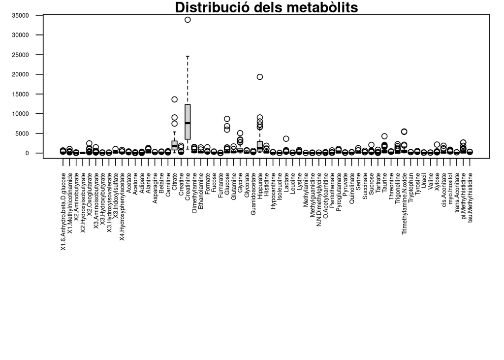

```r
# Representació gràfica de la distribució dels metabòlits
par(mar=c(14, 3, 1, 1))
boxplot(assay(se), main="Distribució dels metabòlits", las=2, cex.axis=0.5)
```